# Sub-Reviews

Alexander Cardazzi

## Incomplete Crawls

```r
g <- aggregate(rev$link, list(rev$company), function(x) length(unique(x)))
g$from_raw <- raw$pages_to_scrape[match(g$Group.1, raw$company)] + 1
g$perc_done <- g$x*100/g$from_raw
```

We were talking about that quirk in the sorting of firms on GD. I wanted to look at the distribution of completion percentages. 76.47% of firms are 100% complete. 96.55% of firms are greater than 80% complete. I also generated an empirical CDF of % Complete.

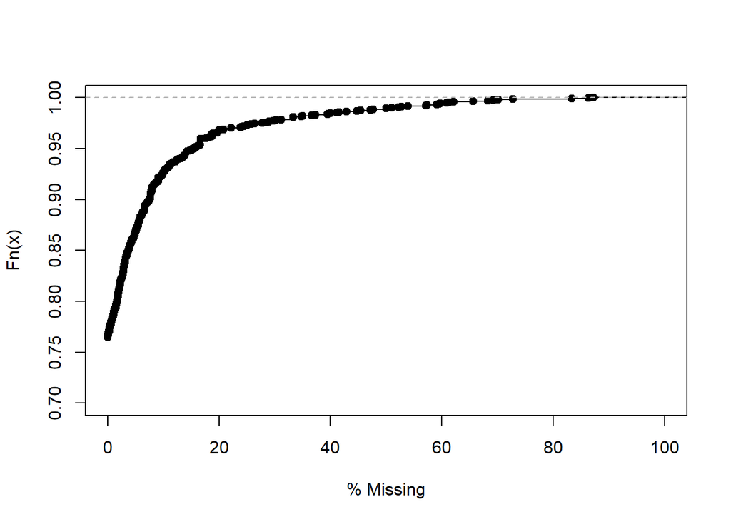

```r
plot(ecdf(100 - g$perc_done), xlim = c(0, 100),
     main = "", xlab = "% Missing", ylim = c(.7, 1))
```

Below are the 20 firms with the worst completion percentage. `x` is the number of crawled pages, `from_raw` is the number of pages expected, and `perc_done` is `x/from_raw`. Second, I plot the `from_raw` against `perc_done` so we can see the relationship between these two measures.

```
##                            Group.1   x from_raw perc_done
## 1070               Macquarie-Group  24      188  12.76596
## 1515                     Santander 118      864  13.65741
## 889     Information-Services-Group   4       24  16.66667
## 1159 Molson-Coors-Beverage-Company  12       44  27.27273
## 1016            Laureate-Education  29       97  29.89691
## 30                           Adobe 153      498  30.72289
## 640                     ExxonMobil 148      466  31.75966
## 1153                       Model-N  11       32  34.37500
## 1932                       Zendesk  25       66  37.87879
## 1171            Motorola-Solutions  97      250  38.80000
## 66         Alexion-Pharmaceuticals  18       46  39.13043
## 1260                        NVIDIA 116      288  40.27778
## 995            Kraft-Heinz-Company 167      412  40.53398
## 1236                           NIC   9       22  40.90909
## 1214                        NetApp 152      356  42.69663
## 1874                       Welbilt   3        7  42.85714
## 1416                      PVH-Corp  53      115  46.08696
## 644                       Facebook 269      569  47.27592
## 1446                      RealPage  53      111  47.74775
## 1436                  Ralph-Lauren 122      249  48.99598
```

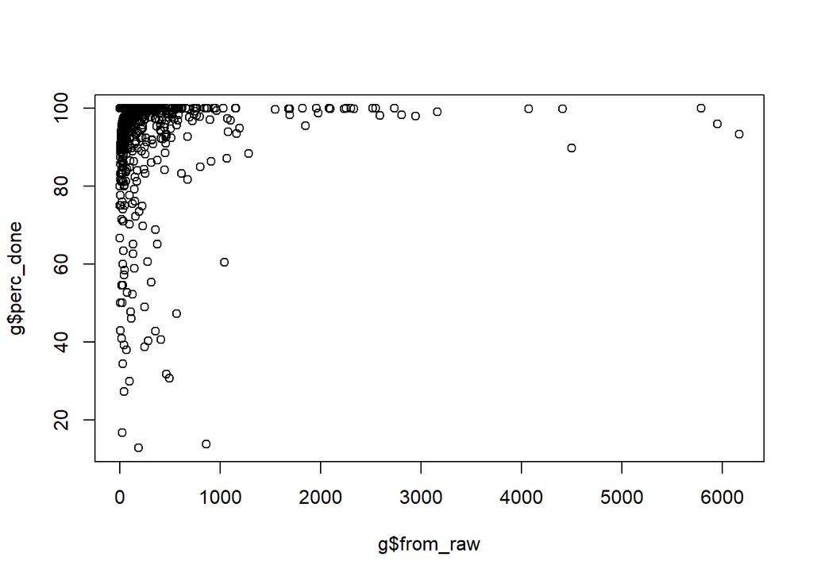

```r
g[order(g$perc_done)[1:20],]
plot(g$from_raw, g$perc_done)
```

## Sub-ratings

Below are relative frequency trends for different sub-rating groups. The first plot is the total number of stars. The vertical line denotes May 22nd 2012. This is when GD 1) adds a 5th subcategory (culture and values) and 2) removes the ability to rate subcateogies with half stars. I think I would like to spend some time poking around that cutoff. There is an exogenous shock to company ratings on GD, which we might be able to leverage in an RDD framework. Anyway, throughout the sample, we see pretty different trends in 5 star ratings compared to other ratings.

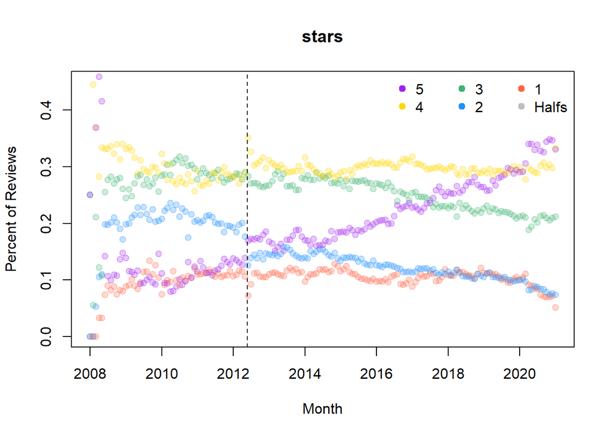

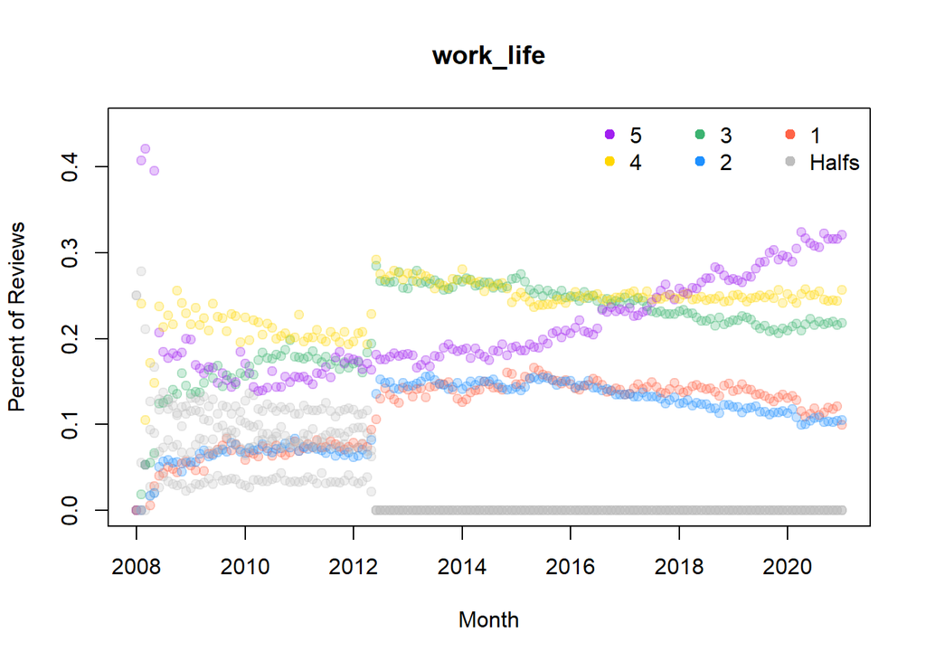

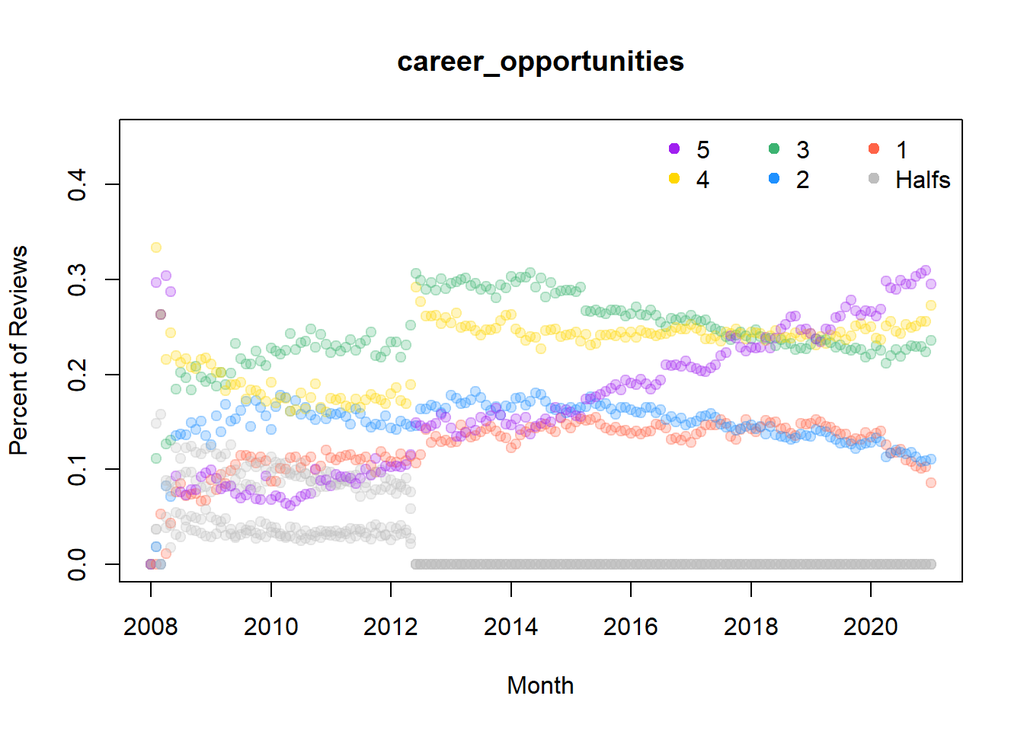

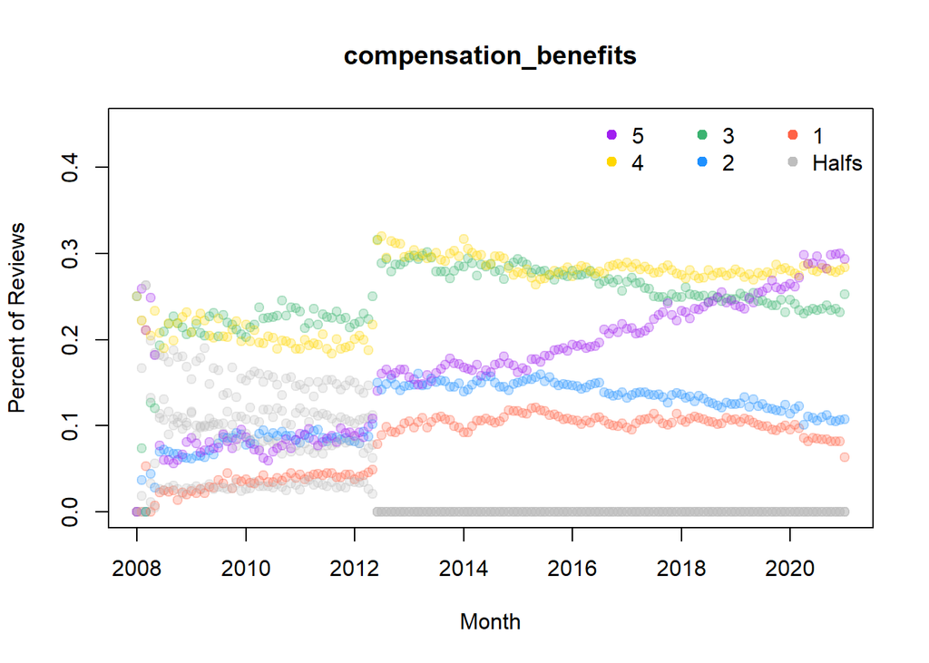

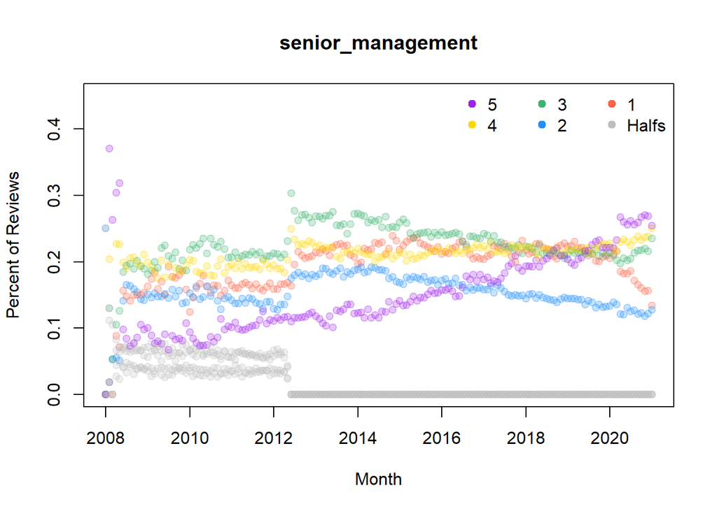

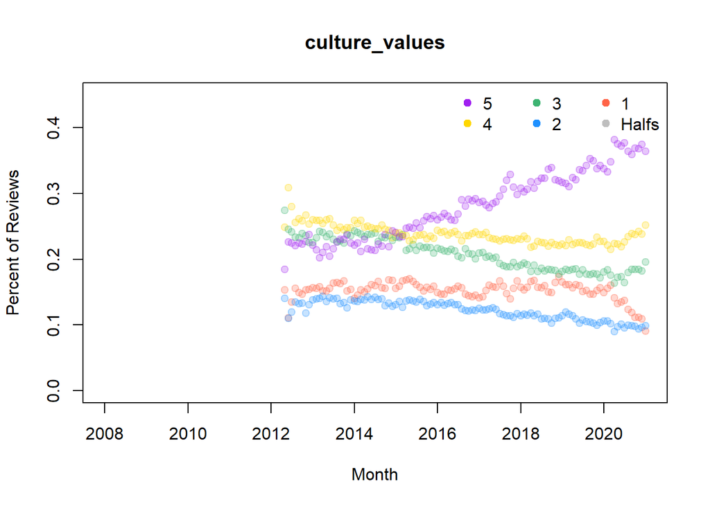

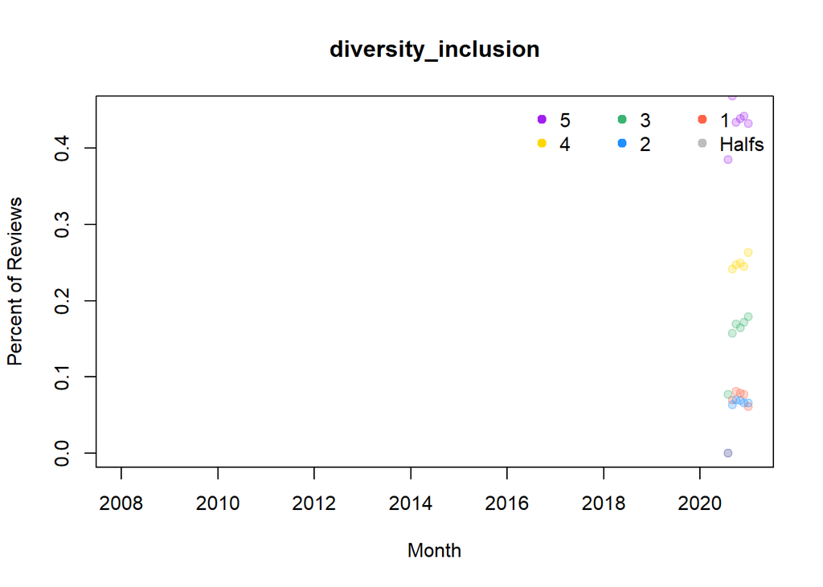

```r
library("scales")
star_percent <- function(col_name){

  lim <- TRUE
  s1 <- as.data.frame(table(rev[lim,c(col_name)], floor_date(rev$timestamp1[lim], "month")))
  s1$Var1 <- as.character(s1$Var1)
  s1$Var2 <- ymd(as.character(s1$Var2))
  s2 <- aggregate(s1$Freq, list(s1$Var2), sum)
  s1$tot <- s2$x[match(s1$Var2, s2$Group.1)]
  colorz <- c("tomato", "DodgerBlue", "MediumSeaGreen", "gold", "purple", rep("grey", 4))
  numz <- c(1:5, 1.5, 2.5, 3.5, 4.5)
  plot(s1$Var2, s1$Freq/s1$tot,
       col = alpha(colorz[match(s1$Var1, numz)], .25), pch = 19,
       ylim = c(0, .45),
       xlab = "Month", ylab = "Percent of Reviews", main = col_name)
  legend("topright", legend = c(5:1, "Halfs"),
         pch = 19, col = c("purple", "gold", "MediumSeaGreen", "DodgerBlue", "tomato", "grey"),
         bty = "n", ncol = 3)
}

star_percent("stars")
abline(v = ymd("2012-05-22"), lty = 2)
par(mfrow = c(1,1))
star_percent("work_life")
star_percent("career_opportunities")
star_percent("compensation_benefits")
star_percent("senior_management")
star_percent("culture_values")
star_percent("diversity_inclusion")
par(mfrow = c(1,1))
```

This next set of plots is looking at how prominant missing subratings are. These trends all appears to mirror each other. It looks like if somebody does not fill out one, they do not fill out them all.

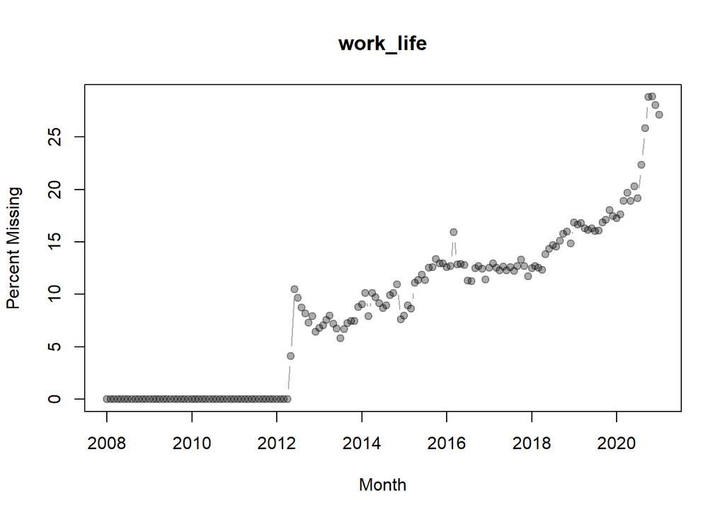

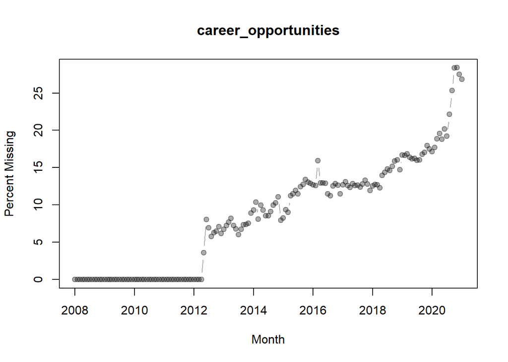

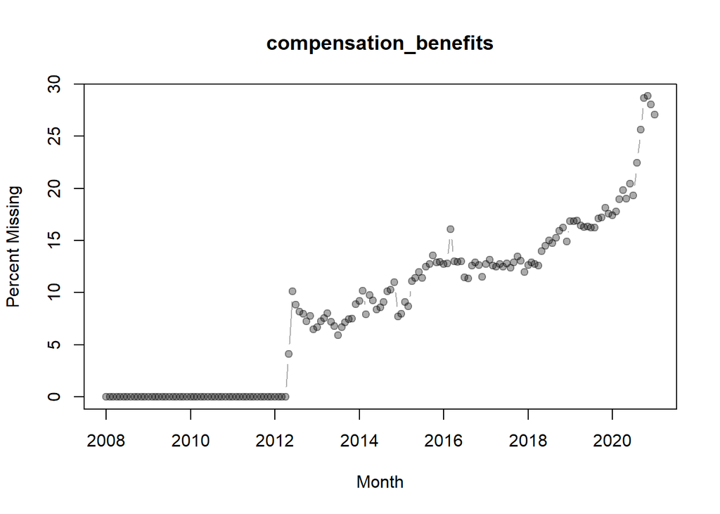

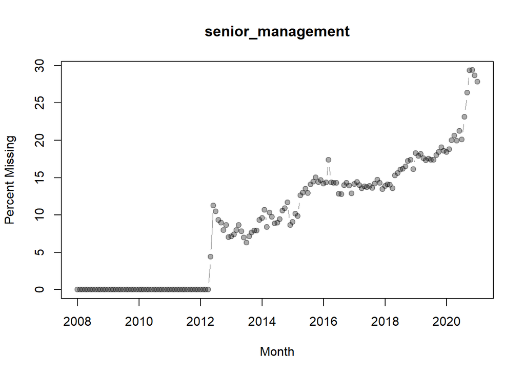

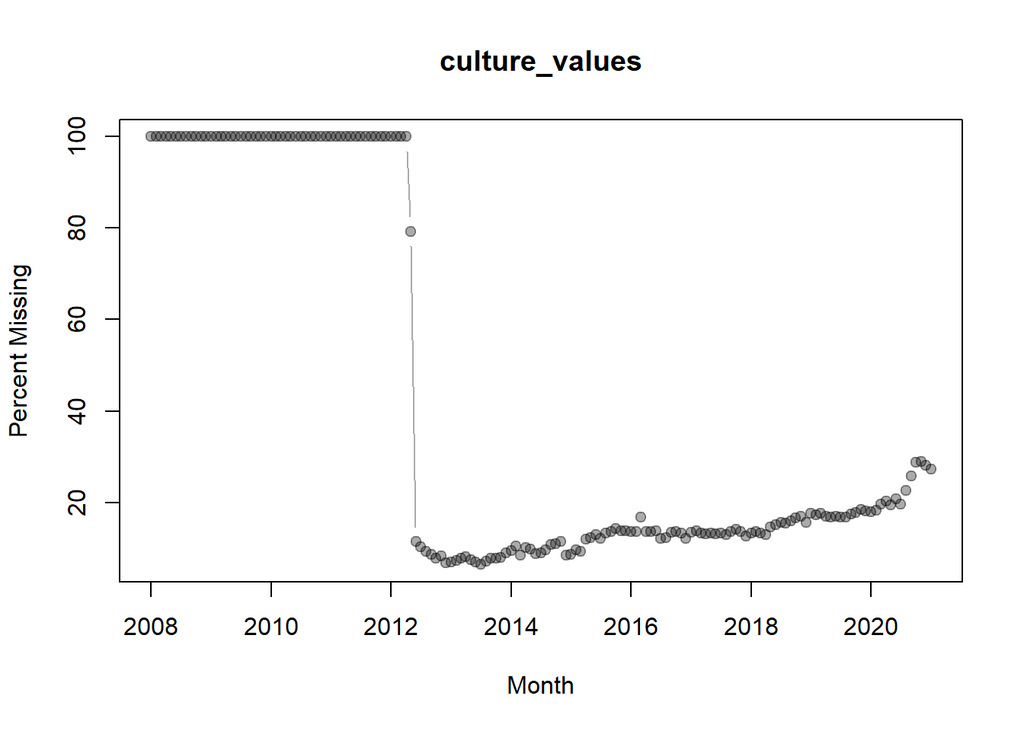

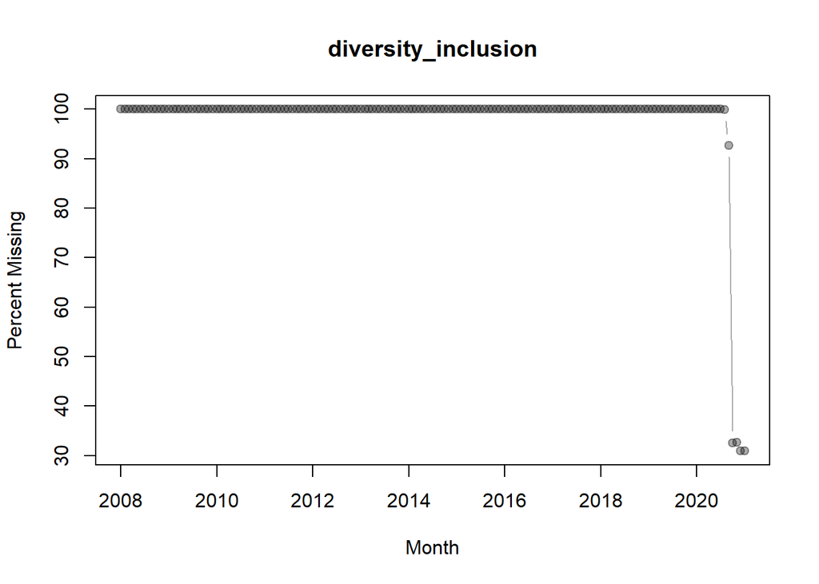

```r
miss_percent <- function(col_name){

  s1 <- aggregate(is.na(rev[,c(col_name)]), list(floor_date(rev$timestamp1, "month")), mean)
  plot(s1$Group.1, 100*s1$x,
       type = "b", pch = 19, main = col_name,
       xlab = "Month", ylab = "Percent Missing",
       col = alpha("black", .33))
}

par(mfrow = c(1,1))

miss_percent("work_life")
miss_percent("career_opportunities")
miss_percent("compensation_benefits")
miss_percent("senior_management")
miss_percent("culture_values")
miss_percent("diversity_inclusion")
par(mfrow = c(1,1))
```

In the following two plots, I find the percent of reviews that have sub-ratings completely missing or completely filled out.

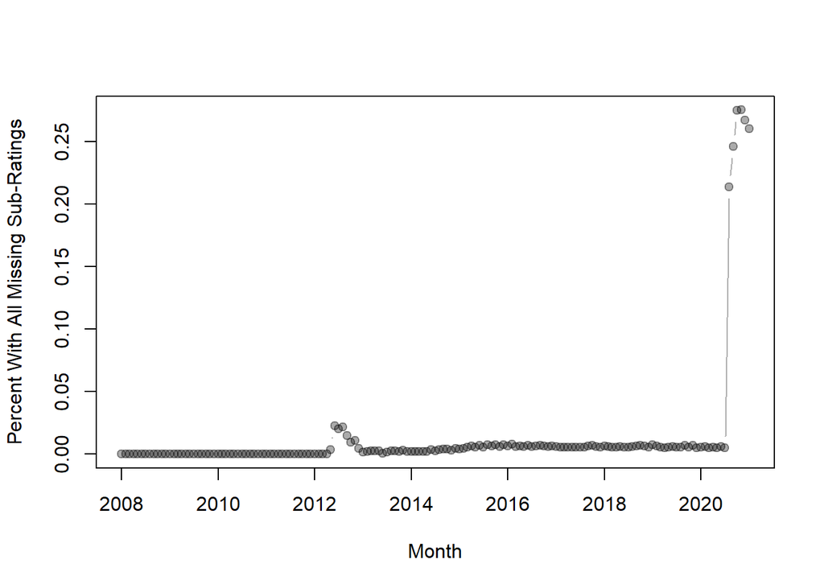

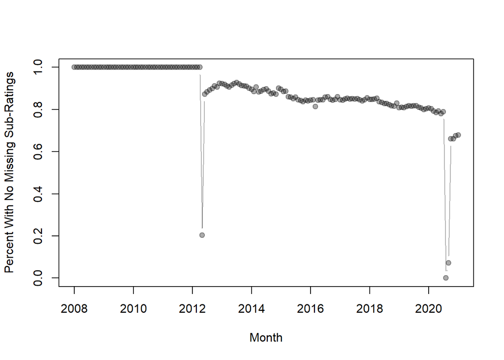

```r
all_names <- c("work_life",
               "career_opportunities",
               "compensation_benefits",
               "senior_management",
               "culture_values",
               "diversity_inclusion")
m_small <- aggregate(rowSums(is.na(rev[,all_names])), list(floor_date(rev$timestamp1, "month")), min)
m_big <- m_small
m_big$x <- 6 - m_small$x

s1 <- aggregate(rowSums(is.na(rev[,all_names])) == m_big$x[match(floor_date(rev$timestamp1, "month"), m_big$Group.1)], list(floor_date(rev$timestamp1, "month")), mean)

s2 <- aggregate(rowSums(is.na(rev[,all_names])) == m_small$x[match(floor_date(rev$timestamp1, "month"), m_small$Group.1)], list(floor_date(rev$timestamp1, "month")), mean)

plot(s1$Group.1, s1$x,
     type = "b", pch = 19, main = "",
     xlab = "Month", ylab = "Percent With All Missing Sub-Ratings",
     col = alpha("black", .33))
plot(s2$Group.1, s2$x,
     type = "b", pch = 19, main = "",
     xlab = "Month", ylab = "Percent With No Missing Sub-Ratings",
     col = alpha("black", .33))
```

This is a plot showing the proportion of reviews where N sub-ratings are filled out. Please keep in mind that the number of sub-ratings possible changes from 4 to 5 (2012-05-22) to 6 (2020-08-26). Until 2012-05-22, every review has all 4 sub-categories filled out. Then, until ~2020, over 80% of reviews have all 5 categories filled out.

```
## [1] "roygbiv"
```

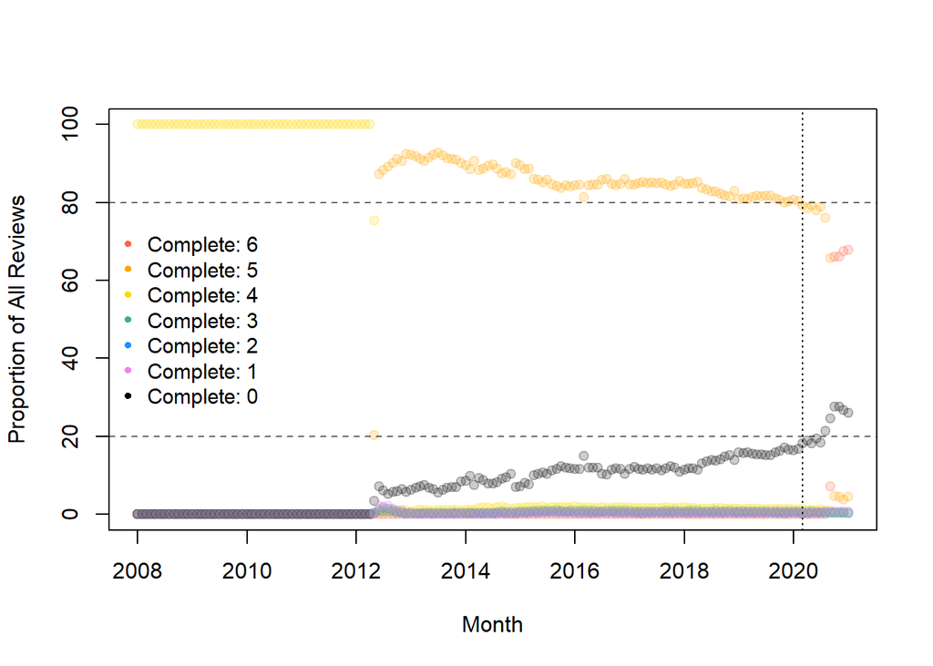

```r
tab <- table(rowSums(is.na(rev[,all_names])), floor_date(rev$timestamp1, "month"))
tab <- as.data.frame(tab)
tab1 <- aggregate(tab$Freq, list(tab$Var2), sum)
tab$relFreq <- tab$Freq*100/tab1$x[match(tab$Var2, tab1$Group.1)]
tab$Var2 <- ymd(as.character(tab$Var2))
tab$Var1 <- as.numeric(as.character(tab$Var1))

"roygbiv"
colz <- c("tomato", "orange", "gold", "mediumseagreen", "dodgerblue", "violet", "black")
plot(tab$Var2, tab$relFreq,
     col = alpha(colz[tab$Var1+1], .2), pch = 19,
     xlab = "Month", ylab = "Proportion of All Reviews")
abline(h = c(80, 20), lty = 2, col = alpha("black", .6))
legend("left", legend = paste0("Complete: ", 6:0),
       col = colz, pch = 20, bty = "n", cex = .95)
abline(v = ymd("2020-03-01"), lty = 3)
```